# Individual Project

Shahmeer Malik

2023-04-21

# INTRODUCTION

Telemarketers will spend hours on the phone calling individuals to promote and sell a product or service to customers. Most of the time, the telemarketers are met with many rejections from their clients, roughly 90% of the calls are unsuccessful. In few cases, they actually succeed in selling their product or service. Our team will be acting as consultants for a telemarketing firm to create a model to help solve the issue of profitability of call centers. Each call made costs $1 to make and each successful call generates $6 in revenue for the firm. We will create a model composed of 3 different sub-models (Logistic Regression Model with backwards stepwise regression, SVM model and Decision Tree modeling), to predict, based on the variables, the likelihood of an individual subscribing to a campaign in order make the business profitable. If we can predict whether a customer is likely to buy or not, we can focus our tele-marketing efforts towards more willing buyers and save/make a ton of money.

The data set consists of 41188 data points separate into 22 variables. Before we can work with the data, we needed to clean the data set.

# READ AND CLEAN THE DATA

```r
telefile <- read.csv("tele copy.csv", stringsAsFactors = TRUE)
summary(telefile)
```

```
##        X              age                 job            marital
##  Min.   :    1   Min.   :17.00   admin.     :10422   divorced: 4612
##  1st Qu.:10298   1st Qu.:32.00   blue-collar: 9254   married :24928
##  Median :20595   Median :38.00   technician : 6743   single  :11568
##  Mean   :20595   Mean   :40.02   services   : 3969   unknown :   80
##  3rd Qu.:30891   3rd Qu.:47.00   management : 2924
##  Max.   :41188   Max.   :98.00   retired    : 1720
##                                  (Other)    : 6156
##                education        default         housing           loan
##  university.degree  :12168   no     :32588   no     :18622   no     :33950
##  high.school        : 9515   unknown: 8597   unknown:  990   unknown:  990
##  basic.9y           : 6045   yes    :    3   yes    :21576   yes    : 6248
##  professional.course: 5243
##  basic.4y           : 4176
##  basic.6y           : 2292
##  (Other)            : 1749
##       contact          month       day_of_week    duration
##  cellular :26144   may    :13769   fri:7827    Min.   :   0.0
##  telephone:15044   jul    : 7174   mon:8514    1st Qu.: 102.0
##                    aug    : 6178   thu:8623    Median : 180.0
##                    jun    : 5318   tue:8090    Mean   : 258.3
##                    nov    : 4101   wed:8134    3rd Qu.: 319.0
##                    apr    : 2632               Max.   :4918.0
##                    (Other): 2016
##     campaign          pdays          previous            poutcome
##  Min.   : 1.000   Min.   :  0.0   Min.   :0.000   failure    : 4252
##  1st Qu.: 1.000   1st Qu.:999.0   1st Qu.:0.000   nonexistent:35563
##  Median : 2.000   Median :999.0   Median :0.000   success    : 1373
##  Mean   : 2.568   Mean   :962.5   Mean   :0.173
##  3rd Qu.: 3.000   3rd Qu.:999.0   3rd Qu.:0.000
##  Max.   :56.000   Max.   :999.0   Max.   :7.000
##
##   emp.var.rate      cons.price.idx  cons.conf.idx     euribor3m
##  Min.   :-3.40000   Min.   :92.20   Min.   :-50.8   Min.   :0.634
##  1st Qu.:-1.80000   1st Qu.:93.08   1st Qu.:-42.7   1st Qu.:1.344
##  Median : 1.10000   Median :93.75   Median :-41.8   Median :4.857
##  Mean   : 0.08189   Mean   :93.58   Mean   :-40.5   Mean   :3.621
##  3rd Qu.: 1.40000   3rd Qu.:93.99   3rd Qu.:-36.4   3rd Qu.:4.961
##  Max.   : 1.40000   Max.   :94.77   Max.   :-26.9   Max.   :5.045
##
##   nr.employed     y
##  Min.   :4964   no :36548
##  1st Qu.:5099   yes: 4640
##  Median :5191
##  Mean   :5167
##  3rd Qu.:5228
##  Max.   :5228
##
```

```r
# Clean data a bit
telefile$X <- NULL
telefile$duration <- NULL
# Create dummy for pdays
telefile$pdaysdummy <- ifelse(telefile$pdays == 999, 0, 1)
telefile$pdays <- NULL


telefile$education <- NULL
telefile$euribor3m <- NULL
telefile$marital <- NULL
telefile$campaign <- NULL
telefile$day_of_week <- NULL
telefile$month <- NULL
telefile$contact <- NULL
str(telefile)
```

```
## 'data.frame':    41188 obs. of  13 variables:
##  $ age           : int  56 57 37 40 56 45 59 41 24 25 ...
##  $ job           : Factor w/ 12 levels "admin.","blue-collar",..: 4 8 8 1 8 8 1 2 10 8 ...
##  $ default       : Factor w/ 3 levels "no","unknown",..: 1 2 1 1 1 2 1 2 1 1 ...
##  $ housing       : Factor w/ 3 levels "no","unknown",..: 1 1 3 1 1 1 1 1 3 3 ...
##  $ loan          : Factor w/ 3 levels "no","unknown",..: 1 1 1 1 3 1 1 1 1 1 ...
##  $ previous      : int  0 0 0 0 0 0 0 0 0 0 ...
##  $ poutcome      : Factor w/ 3 levels "failure","nonexistent",..: 2 2 2 2 2 2 2 2 2 2 ...
##  $ emp.var.rate  : num  1.1 1.1 1.1 1.1 1.1 1.1 1.1 1.1 1.1 1.1 ...
##  $ cons.price.idx: num  94 94 94 94 94 ...
##  $ cons.conf.idx : num  -36.4 -36.4 -36.4 -36.4 -36.4 -36.4 -36.4 -36.4 -36.4 -36.4 ...
##  $ nr.employed   : num  5191 5191 5191 5191 5191 ...
##  $ y             : Factor w/ 2 levels "no","yes": 1 1 1 1 1 1 1 1 1 1 ...
##  $ pdaysdummy    : num  0 0 0 0 0 0 0 0 0 0 ...
```

# CONVERTING FACTORS INTO DUMMY VARIABLES

```r
telemm <- as.data.frame(model.matrix(~.-1,telefile))
str(telemm)
```

```
## 'data.frame':    41188 obs. of  28 variables:
##  $ age                : num  56 57 37 40 56 45 59 41 24 25 ...
##  $ jobadmin.          : num  0 0 0 1 0 0 1 0 0 0 ...
##  $ jobblue-collar     : num  0 0 0 0 0 0 0 1 0 0 ...
##  $ jobentrepreneur    : num  0 0 0 0 0 0 0 0 0 0 ...
##  $ jobhousemaid       : num  1 0 0 0 0 0 0 0 0 0 ...
##  $ jobmanagement      : num  0 0 0 0 0 0 0 0 0 0 ...
##  $ jobretired         : num  0 0 0 0 0 0 0 0 0 0 ...
##  $ jobself-employed   : num  0 0 0 0 0 0 0 0 0 0 ...
##  $ jobservices        : num  0 1 1 0 1 1 0 0 0 1 ...
##  $ jobstudent         : num  0 0 0 0 0 0 0 0 0 0 ...
##  $ jobtechnician      : num  0 0 0 0 0 0 0 0 1 0 ...
##  $ jobunemployed      : num  0 0 0 0 0 0 0 0 0 0 ...
##  $ jobunknown         : num  0 0 0 0 0 0 0 0 0 0 ...
##  $ defaultunknown     : num  0 1 0 0 0 1 0 1 0 0 ...
##  $ defaultyes         : num  0 0 0 0 0 0 0 0 0 0 ...
##  $ housingunknown     : num  0 0 0 0 0 0 0 0 0 0 ...
##  $ housingyes         : num  0 0 1 0 0 0 0 0 1 1 ...
##  $ loanunknown        : num  0 0 0 0 0 0 0 0 0 0 ...
##  $ loanyes            : num  0 0 0 0 1 0 0 0 0 0 ...
##  $ previous           : num  0 0 0 0 0 0 0 0 0 0 ...
##  $ poutcomenonexistent: num  1 1 1 1 1 1 1 1 1 1 ...
##  $ poutcomesuccess    : num  0 0 0 0 0 0 0 0 0 0 ...
##  $ emp.var.rate       : num  1.1 1.1 1.1 1.1 1.1 1.1 1.1 1.1 1.1 1.1 ...
##  $ cons.price.idx     : num  94 94 94 94 94 ...
##  $ cons.conf.idx      : num  -36.4 -36.4 -36.4 -36.4 -36.4 -36.4 -36.4 -36.4 -36.4 -36.4 ...
##  $ nr.employed        : num  5191 5191 5191 5191 5191 ...
##  $ yyes               : num  0 0 0 0 0 0 0 0 0 0 ...
##  $ pdaysdummy         : num  0 0 0 0 0 0 0 0 0 0 ...
```

# NORMALIZING AND CREATING TEST AND TRAIN SET

In order to make the data more streamlined and easier to work on, the best approach would be to normalize all the data, then create a test set from the normalized data which is half the size of the original on a predetermined seed of “12345”. After, we remove the yyes column from the test set and create a train and test for the original data and remove the yyes column from it. They will be stored separately in a label list for each train and test that will be added back for each different prediciton model.

```r
# Randomize the rows in the data (shuffling the rows)
set.seed(12345)
tele_random <- telemm[sample(nrow(telemm)),]
#Normalize the data
normalize <- function(x) {
  return ((x - min(x)) / (max(x) - min(x)))
}
# We are going to normalize everything
tele_norm <- as.data.frame(lapply(tele_random, normalize))
# Select 50% of the total number of rows for test data
set.seed(12345)
test_set <- sample(1:nrow(tele_norm), nrow(tele_norm)*0.5)
# Create a train set and test set
#First the predictors - all columns except the yyes column
tele_train <- tele_norm[-test_set, -match("yyes",names(tele_norm))]
tele_test  <- tele_norm[test_set, -match("yyes",names(tele_norm))]
#Now the response (aka Labels) - only the yyes column
tele_train_labels <- tele_norm[-test_set, "yyes"]
tele_test_labels  <- tele_norm[test_set, "yyes"]
```

# LOGISTIC REGRESSION

Now that we have the data, we’ll create a logistical regression model and apply that to step wise backward regression. well make predictions using the optimization and if the value is over 0.5 for each iteration, then we set the value to 1, otherwise its 0. This will convert the prediction into a binary model of 0 and 1 after factorizing to be used later.

```
## Start:  AIC=11701.88
## yyes ~ age + jobadmin. + jobblue.collar + jobentrepreneur + jobhousemaid +
##     jobmanagement + jobretired + jobself.employed + jobservices +
##     jobstudent + jobtechnician + jobunemployed + jobunknown +
##     defaultunknown + defaultyes + housingunknown + housingyes +
##     loanunknown + loanyes + previous + poutcomenonexistent +
##     poutcomesuccess + emp.var.rate + cons.price.idx + cons.conf.idx +
##     nr.employed + pdaysdummy
##
##
## Step:  AIC=11701.88
## yyes ~ age + jobadmin. + jobblue.collar + jobentrepreneur + jobhousemaid +
##     jobmanagement + jobretired + jobself.employed + jobservices +
##     jobstudent + jobtechnician + jobunemployed + jobunknown +
##     defaultunknown + defaultyes + housingunknown + housingyes +
##     loanyes + previous + poutcomenonexistent + poutcomesuccess +
##     emp.var.rate + cons.price.idx + cons.conf.idx + nr.employed +
##     pdaysdummy
##
##
## Step:  AIC=11701.88
## yyes ~ age + jobadmin. + jobblue.collar + jobentrepreneur + jobhousemaid +
##     jobmanagement + jobretired + jobself.employed + jobservices +
##     jobstudent + jobtechnician + jobunemployed + defaultunknown +
##     defaultyes + housingunknown + housingyes + loanyes + previous +
##     poutcomenonexistent + poutcomesuccess + emp.var.rate + cons.price.idx +
##     cons.conf.idx + nr.employed + pdaysdummy
##
##                       Df Deviance   AIC
## - jobmanagement        1    11650 11700
## - previous             1    11650 11700
## - jobself.employed     1    11650 11700
## - jobadmin.            1    11650 11700
## - jobtechnician        1    11650 11700
## - defaultyes           1    11650 11700
## - housingunknown       1    11650 11700
## - loanyes              1    11650 11700
## - jobretired           1    11650 11700
## - jobunemployed        1    11650 11700
## - jobhousemaid         1    11650 11700
```

[output cut: 340 more lines]

```
##                       Df Deviance   AIC
## <none>                      11654 11682
## - jobentrepreneur      1    11658 11684
## - jobstudent           1    11660 11686
## - jobretired           1    11661 11687
## - poutcomesuccess      1    11663 11689
## - jobservices          1    11667 11693
## - pdaysdummy           1    11670 11696
## - cons.conf.idx        1    11672 11698
## - cons.price.idx       1    11676 11702
## - jobblue.collar       1    11676 11702
## - nr.employed          1    11680 11706
## - poutcomenonexistent  1    11682 11708
## - defaultunknown       1    11683 11709
## - emp.var.rate         1    11684 11710
```

# SVM model

In order to create the most efficient SVM model we can, this system creates three 3 different predictions for an RBFdot, laplacedot, and polydot kernel. After creating a confusion matrix for all the data, the program stores the matrices of every kernel prediction into a list along with a separate list parallel to the matrices that corresponds to each of their accuracies.

# CHOOSE BEST SVM

```r
bestSVM_index <- which.max(svm_accuracies)
bestSVM_pred <- switch(bestSVM_index,
                       svm_rbf_pred,
                       svm_laplace_pred,
                       svm_poly_pred)
bestSVM_matrix <- confusionMatrix(svm_poly_pred, as.factor(tele_test_labels), positive = "1")
```

# DECISION TREE

The same methodology as the previous two prediction models will be applied for a decision tree prediction scheme.

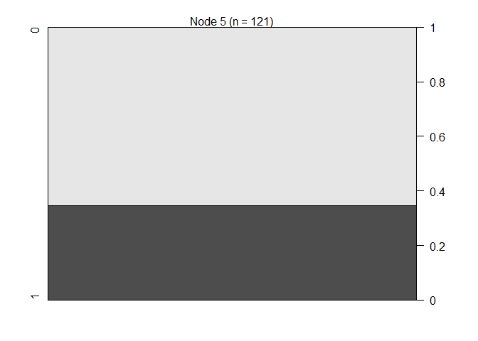

```r
tele_train$yyes <- tele_train_labels
tele_test$yyes <- tele_test_labels
decisionTreeModel <- C5.0(as.factor(yyes) ~ ., data = tele_train)
decisionTreePred <- predict(decisionTreeModel, tele_test)
plot(decisionTreeModel, subtree=5)
```

```r
decisionTreeMatrix <-confusionMatrix(decisionTreePred, as.factor(tele_test_labels), positive="1")
```

# COMBINE ALL THREE MODELS INTO ONE

All the confusion matrices accuracies are printed here to show what they looked like before being joined into one model. It’s observed that the logisitics model has an accuracy of 89.85%, the SVM model has an accuracy of 89.70% and the decision tree has an accuracy of 89.88%.

```r
logisticsMatrix
```

```
## Confusion Matrix and Statistics
##
##           Reference
## Prediction     0     1
##          0 18093  1917
##          1   173   411
##
##                Accuracy : 0.8985
##                  95% CI : (0.8943, 0.9026)
##     No Information Rate : 0.887
##     P-Value [Acc > NIR] : 5.636e-08
##
##                   Kappa : 0.2482
##
##  Mcnemar's Test P-Value : < 2.2e-16
##
##             Sensitivity : 0.17655
##             Specificity : 0.99053
##          Pos Pred Value : 0.70377
##          Neg Pred Value : 0.90420
##              Prevalence : 0.11304
##          Detection Rate : 0.01996
##    Detection Prevalence : 0.02836
##       Balanced Accuracy : 0.58354
##
##        'Positive' Class : 1
##
```

```r
bestSVM_matrix
```

```
## Confusion Matrix and Statistics
##
##           Reference
## Prediction     0     1
##          0 18000  1855
##          1   266   473
##
##                Accuracy : 0.897
##                  95% CI : (0.8928, 0.9011)
##     No Information Rate : 0.887
##     P-Value [Acc > NIR] : 2.087e-06
##
##                   Kappa : 0.2686
##
##  Mcnemar's Test P-Value : < 2.2e-16
##
##             Sensitivity : 0.20318
##             Specificity : 0.98544
##          Pos Pred Value : 0.64005
##          Neg Pred Value : 0.90657
##              Prevalence : 0.11304
##          Detection Rate : 0.02297
##    Detection Prevalence : 0.03588
##       Balanced Accuracy : 0.59431
##
##        'Positive' Class : 1
##
```

```r
decisionTreeMatrix
```

```
## Confusion Matrix and Statistics
##
##           Reference
## Prediction     0     1
##          0 18121  1940
##          1   145   388
##
##                Accuracy : 0.8988
##                  95% CI : (0.8946, 0.9028)
##     No Information Rate : 0.887
##     P-Value [Acc > NIR] : 3.005e-08
##
##                   Kappa : 0.2392
##
##  Mcnemar's Test P-Value : < 2.2e-16
##
##             Sensitivity : 0.16667
##             Specificity : 0.99206
##          Pos Pred Value : 0.72795
##          Neg Pred Value : 0.90329
##              Prevalence : 0.11304
##          Detection Rate : 0.01884
##    Detection Prevalence : 0.02588
##       Balanced Accuracy : 0.57936
##
##        'Positive' Class : 1
##
```

# CREATE A CONFUSION MATRIX

```r
# Combine the predictions using voting, but only predict a 1 if all three models predict a 1

ensemble_pred <- ifelse( as.numeric(bestSVM_pred) + as.numeric(logisticsPred) + as.numeric(decisionTreePred)  == 3, 0, 1)

# Create a confusion matrix
ensemble_matrix <- confusionMatrix(as.factor(ensemble_pred), as.factor(tele_train_labels), positive="1")
# View the confusion matrix
ensemble_matrix
```

```
## Confusion Matrix and Statistics
##
##           Reference
## Prediction     0     1
##          0 17718  2251
##          1   564    61
##
##                Accuracy : 0.8633
##                  95% CI : (0.8585, 0.868)
##     No Information Rate : 0.8877
##     P-Value [Acc > NIR] : 1
##
##                   Kappa : -0.0066
##
##  Mcnemar's Test P-Value : <2e-16
##
##             Sensitivity : 0.026384
##             Specificity : 0.969150
##          Pos Pred Value : 0.097600
##          Neg Pred Value : 0.887275
##              Prevalence : 0.112266
##          Detection Rate : 0.002962
##    Detection Prevalence : 0.030349
##       Balanced Accuracy : 0.497767
##
##        'Positive' Class : 1
##
```

# EXAMPLE

```r
# Set seed for reproducibility
set.seed(12345)

# Randomly select 10 rows from tele_test
random_subset <- tele_test[sample(nrow(tele_test), 10), ]
random_subset_labels <- tele_test_labels[sample(nrow(tele_test), 10)]

# Make predictions on the subset using the model with selected variables
logisticsPred_subset <- predict(logistics_m_backward, random_subset, type = "response")
logisticsPred_subset <- ifelse(logisticsPred_subset >= 0.5, "1", "0")
logisticsPred_subset <- as.factor(logisticsPred_subset)
names(logisticsPred_subset) <- NULL

logisticsPred_subset
```

```
##  [1] 0 0 0 0 0 0 0 0 0 0
## Levels: 0
```

```r
# Calculate confusion matrix to evaluate model performance on the subset
logisticsMatrix_subset <- confusionMatrix(logisticsPred_subset, as.factor(random_subset_labels), positive = "1")
logisticsMatrix_subset
```

```
## Confusion Matrix and Statistics
##
##           Reference
## Prediction 0 1
##          0 9 1
##          1 0 0
##
##                Accuracy : 0.9
##                  95% CI : (0.555, 0.9975)
##     No Information Rate : 0.9
##     P-Value [Acc > NIR] : 0.7361
##
##                   Kappa : 0
##
##  Mcnemar's Test P-Value : 1.0000
##
##             Sensitivity : 0.0
##             Specificity : 1.0
##          Pos Pred Value : NaN
##          Neg Pred Value : 0.9
##              Prevalence : 0.1
##          Detection Rate : 0.0
##    Detection Prevalence : 0.0
##       Balanced Accuracy : 0.5
##
##        'Positive' Class : 1
##
```

# CONCLUSION